# Exploring the BRFSS data

## Setup

### Load packages

`{r load-packages, message = FALSE} library(ggplot2) library(dplyr)`

### Load data

Make sure your data and R Markdown files are in the same directory. When loaded your data file will be called `brfss2013`. Delete this note when before you submit your work.

`{r load-data} load("brfss2013.RData")`

## Part 1: Data

The data was collected via random telephone calls in different states of the US. This amounts to a **fairly** random sample, that may be generalizable to the larger population. The sample may still suffer from selection bias/convenience bias since only US residents with access to a cellphone or a landline phone are in the sample. There is also the factor of volunteer bias as some participants with cellphone/landline access may have preferred to decline the survey, or not answer certain questions.

Since this is purely an observational study, and not an experiment, the question of random assignment does not arise. Causality can only be inferred from experiments with control and study groups, where random assignment is possible in the groups.

## Part 2: Research questions

**Research quesion 1:** Does inactivity or lack of activity increase the risk of being diagnosed with a heart attack, stroke or coronary heart disease as compared to active people?

This question is of interest to us from a medical and general fitness perspective as it answers the fundamental question of whether physical activity is beneficial for the heart.

**Research quesion 2:** Which states have the highest percentage of smokers (regular or non-regular) among the respondents from that state?

This question is of interest to us as it would help direct anti-smoking campaigns and possible public smoking bans in states with high percentage of smokers.

**Research quesion 3:** Do family households (family households defined as households with numadult > 1) with higher income generally tend to be healthier, based on what they report in the survey?

## Part 3: Exploratory data analysis

NOTE: Insert code chunks as needed by clicking on the “Insert a new code chunk” button (green button with orange arrow) above. Make sure that your code is visible in the project you submit. Delete this note when before you submit your work.

**Research quesion 1:**

The variables from the dataset that are of interest to us in this question are:

*cvdinfr4*: Ever Diagnosed With Heart Attack

*cvdcrhd4*: Ever Diagnosed With Angina Or Coronary Heart Disease

*cvdstrk3*: Ever Diagnosed With A Stroke

and the calculated variable:

*_pacat1*: Physical Activity Categories

**Methodology:**  
_pacat1 (which is automatically renamed to X_pacat1) indicates the level of physical activity of a participant: **“Highly Active”**, **“Active”**, **“Insufficiently Active”**, **“Inactive”**

The variable cvdinfr4 indicates whether the participant has even diagnosed with a heart attack (if “Yes”). The variable cvdcrhd4 indicates whether the participant has ever been diagnosed with angina or coronary heart disease (if “Yes”) The variable cvdstrk3 indicates whether the participant has ever been diagnosed with a stroke (if “Yes”)

We create 3 separate data frames from the base data frame with the following variables, by selecting only the necessary variables: Data frame 1: (_pacat1, cvdinfr4) Data frame 2: (_pacat1, cvdcrhd4) Data frame 3: (_pacat1, cvdstrk3)

Next, we remove any NA values from the data frames in any variable column by filtering. Now for each data frame, we group by variable *_pacat1* and the corresponding cvd variable. And then summarize to get the groupwise count.

Once we have the groupwise count, we would now like to calculate the proportion of participants in each of the levels of physical activity who have been diagnosed with the disease. So for each data frame, we now have the proportion of participants diagnosed with a disease for each physical activity level. We can now plot these in separate bar graphs.

**Plots:**

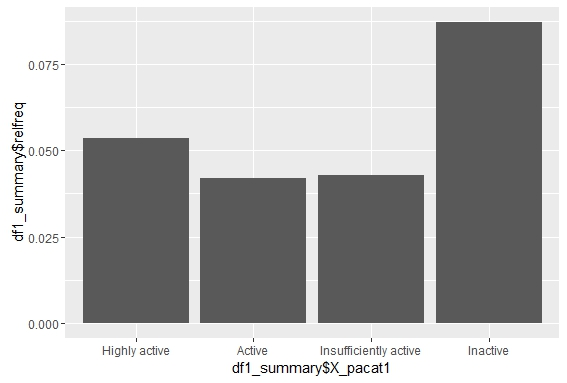

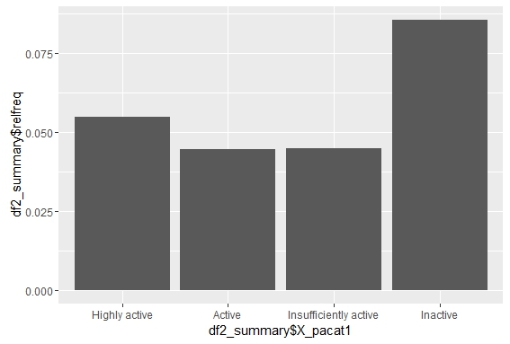

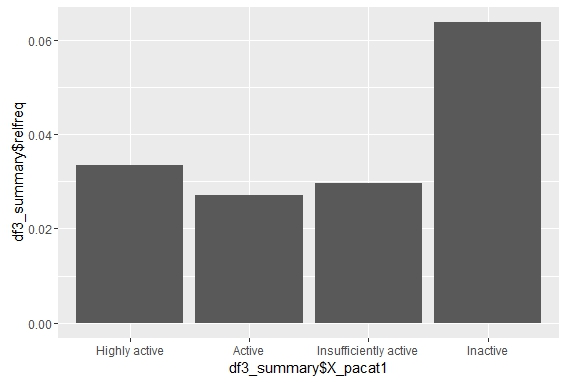

**Conclusion:** As evident from the graphs, participants who were classified as “Inactive” have a higher probability of being diagnosed with heart attack, stroke or coronary heart disease.  
**Code:**

```r
df1 <- brfss2013 %>% select(X_pacat1, cvdinfr4) # Data frame 1
df2 <- brfss2013 %>% select(X_pacat1, cvdcrhd4) # Data frame 2
df3 <- brfss2013 %>% select(X_pacat1, cvdstrk3) # Data frame 3

# Remove any NA values from the data sets
df1 <- df1 %>% filter(!is.na(X_pacat1)) %>% filter(!is.na(cvdinfr4))
df2 <- df2 %>% filter(!is.na(X_pacat1)) %>% filter(!is.na(cvdcrhd4))
df3 <- df3 %>% filter(!is.na(X_pacat1)) %>% filter(!is.na(cvdstrk3))

# Group each data frame by X_pacat1 and the corresponding variable
# and then generate summarize using count=n()
df1_summary <- df1 %>% group_by(X_pacat1, cvdinfr4) %>% summarize(count=n())
df2_summary <- df2 %>% group_by(X_pacat1, cvdcrhd4) %>% summarize(count=n())
df3_summary <- df3 %>% group_by(X_pacat1, cvdstrk3) %>% summarize(count=n())

# From the summaries above, for each group of X_pacat1, calculate the proportion
# of the corresponding cvd variable that have value "Yes"
df1_summary <- summarize(df1_summary, relfreq=count[cvdinfr4=="Yes"]/sum(count))
df2_summary <- summarize(df2_summary, relfreq=count[cvdcrhd4=="Yes"]/sum(count))
df3_summary <- summarize(df3_summary, relfreq=count[cvdstrk3=="Yes"]/sum(count))

# At this point, we have for each activity group, the corresponding percentage
# of participants that have been diagnosed with the particular heart problem
# We plot these in bar plots for each data frame

df1_summary %>% ggplot(aes(x=df1_summary$X_pacat1, y=df1_summary$relfreq)) + geom_bar(stat="identity")
df2_summary %>% ggplot(aes(x=df2_summary$X_pacat1, y=df2_summary$relfreq)) + geom_bar(stat="identity")
df3_summary %>% ggplot(aes(x=df3_summary$X_pacat1, y=df3_summary$relfreq)) + geom_bar(stat="identity")
```

**Research quesion 2:**

The variables of interest for this question are:

*X_state*: The state the respondent belongs to

*smokday2*: Frequency of smoking for the respondent

**Methodology:**  
If the respondent has responded to *smokday2* as either “Every day” or “Some days”, we consider the respondent as a smoker. We calculate the proportion of smokers in a state as the proportion of respondents with “Every day” and “Some days” over the sum of non-NA responders (i.e. “Every day” + “Some days” + “Not at all”)  
Also, before creating a bar plot of the resulting data, we may want to find out the 3 states with the highest percentage of smokers and 3 states with the lowest percentage of smokers.

**Conclusion:** The top 3 smoking states are:

1. ```
               Guam 0.5710526
   ```

2. ```
      West Virginia 0.4703490
   ```

3. ```
           Kentucky 0.4494447
   ```

The 3 lowest smoking states are:

1. New Hampshire 0.2666667

2. ```
        Vermont 0.2884805
   ```

3. ```
    Puerto Rico 0.2934974
   ```

**Plot:**  
The bar plot for the data:

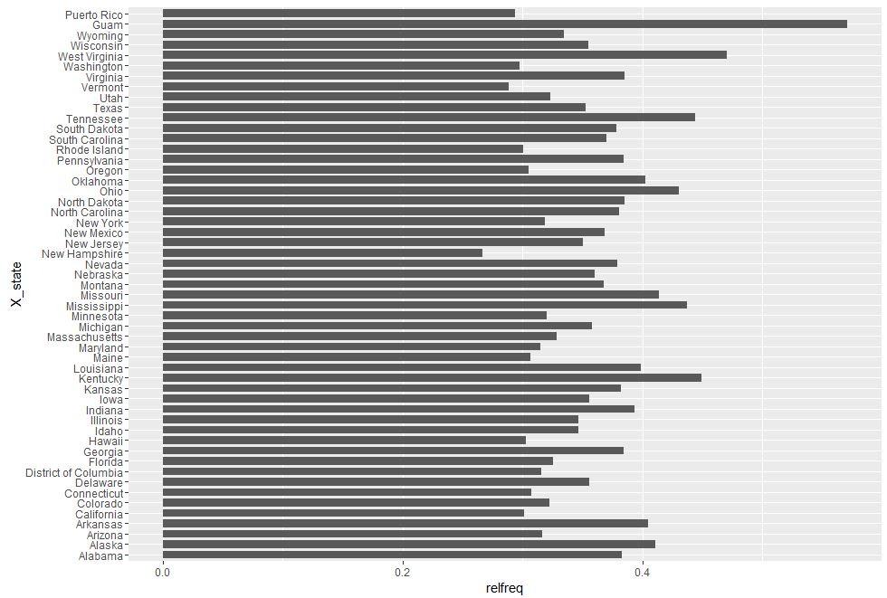

**Code:**

```r
# Select necessary variables and remove NAs
temp_data <- brfss2013 %>% select(X_state, smokday2) %>% filter(!is.na(X_state)) %>% filter(!is.na(smokday2))

# Group temp_data by (state, smokday2) and summarize first to get a count of each smoker type by state
# Next, summarize again to create a relative frequency table of smokers per state
states_with_rfsmokers <- temp_data %>% group_by(X_state, smokday2) %>% summarize(count=n()) %>% summarize(relfreq=1 - (count[smokday2=="Not at all"]/sum(count)))
states_with_rfsmokers <- as.data.frame(states_with_rfsmokers)

# Sort the states_with_rfsmokers data frame in descending order based on the relfreq
states_with_rfsmokers <- states_with_rfsmokers[order(states_with_rfsmokers$relfreq, decreasing = TRUE), ]

# Print the top 3 and the lowest 3 states in the smoking percentage list
states_with_rfsmokers[1:3,]
num_states <- length(states_with_rfsmokers[,1])  # No. of entries in list
states_with_rfsmokers[num_states:(num_states-2),]

# Plot the resulting data in a vertical bar plot
states_with_rfsmokers %>% ggplot(aes(x=X_state, y=relfreq)) + geom_bar(stat="identity", width=0.75) + coord_flip()
```

**Research quesion 3:**

The variables that are of interest to us in this question are:

*numadult*: The number of adults in the household

*genhlth*: The reported health of the participant

*income2*: The reported total annual household income

**Methodology:**  
Assumptions we make for this analysis are:

Households with number of adults greater than or equal to 2 (numadult >= 2) are considered family households.

Also in the dataset, for numadult >= 6, there are too few entries to make a reliable conclusion. So we only consider 2 <= numadult <= 5

The idea is to first create groups based on *income2*, and then sub-groups based on *genhlth*. Next, we get a relative frequency of each *genhlth* sub-group within *income2* groups.

Next, we generate bar plots using faceting in ggplot. Using faceting, we can generate multiple bar charts in the same plot, when we have groups on multiple variables.

**Plots:**  
The first plot shows 5 bar charts one for each *genhlth* category. Within each barchart, we have the income category and its relative frequency.

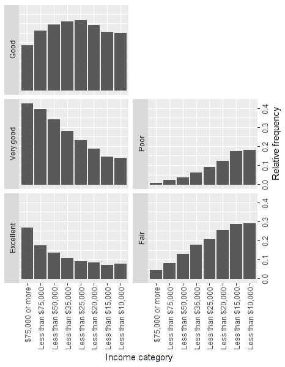

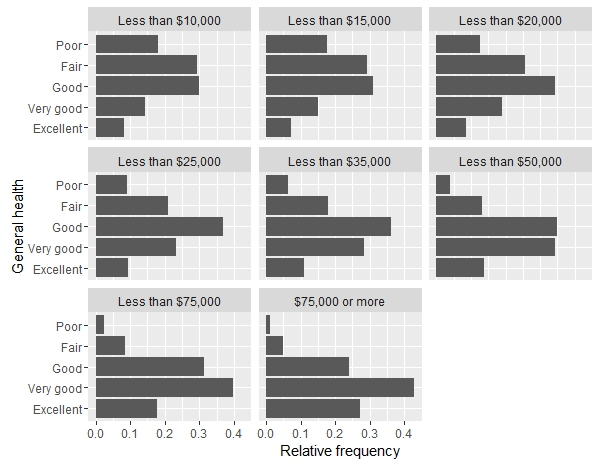

**Conclusion:**  
The pattern we observe from the first plot is that for general health status “Excellent” and “Very good”, the income categories are skewed towards the high income end, and for health statuses “Fair” and “Poor”, the income categories are skewed towards the low income end.

This indicates that high income family households tend to have a better general health than low income family households.

Same can be inferred from the second plot.  
**Code:**

```r
# Select necessary variables from the parent dataset and filter out NA values
df1 <- brfss2013 %>% select(numadult, genhlth, income2)
df1 <- df1 %>% filter(!is.na(numadult)) %>% filter(!is.na(genhlth)) %>% filter(!is.na(income2))

# Filter only for numadult = 2, 3, 4, 5
cv <- c("2", "3", "4", "5")
df1 <- df1 %>% filter(numadult %in% cv)

# Group heirarchically by income and health and summarize using count=n()
# Next, mutate the data frame by adding a new variable 'rf' which gives the
# relative frequency of each genhlth group within each income group
temp <- df1 %>% group_by(income2, genhlth) %>% summarise(count=n()) %>% mutate(rf=count[genhlth]/sum(count))

# Two ways of graphing barplots for the data:

# Barplot based on primary group 'genhlth' and secondary group 'income2'
ggplot(temp, aes(x=income2, y=rf)) + geom_bar(stat="identity") + facet_wrap(~ genhlth) + coord_flip()

# Barplot based on primary group 'income2' and secondary group 'genhlth'
ggplot(temp, aes(x=genhlth, y=rf)) + geom_bar(stat="identity") + facet_wrap(~ income2) + coord_flip()
```